#### **Analysis Report:**

The data for this exploratory data analysis comes from three political subreddits ( r/politics, r/Republicans, and r/democrats) using the Pushshit Reddit API to get text of post and comments, score, number of comments on the post, time of post and more. The original dataset was generated via the Reddit Archive data from January 2021 through the end of August 2022.  
Before analyzing trends across subreddits, data first needed to be cleaned. We followed standard data cleaning procedures - starting with filtering submissions and comments for our relevant subreddits (r/politics, r/Republicans, and r/democrats). Then the number of submissions from each subreddit was subsetted to a randomly selected 20,000 submissions so that each subreddit would have an equal number of submissions. R/politics is a highly populated and used subreddit, far outnumbering r/Republican or r/democrats in the number of posts and comments. Keeping sample sizes consistent across datasets was critical in preventing any bias or skew. Additionally, we kept all the submissions and all the comments in two separate data frames as they were used to answer different questions throughout the study.  
Further data cleaning entailed dropping rows with missing text in posts and comments as analyzing the text is the main component of the study. We chose to keep only the first level comments of the posts from the submission dataset to extract immediate reactions and sentiments about the posts analyzed, rather than including 5th or 6th level replies that were typically less content rich. Basic quality checks were also conducted such as data type conversions, and we dealt with outliers by converting the subreddit column to categorical and the score and number of comments columns to integer values. For basic feature generation, the time of the post variable was converted into a proper data time value and five new variables were created with data transformations on the data time value: [*month, year, time of day, election_year*]. We also extracted critical political topics in national discourse in the form of 4 dummy variables using regex: [*"dummy_police", "dummy_healthcare", "dummy_climate", "dummy_economy"*]. With the data cleaned and prepared, the crux of our exploratory analysis work revolved around the following three EDA business questions.

##### **1. How can we measure “engagement” on Reddit? In what ways do users interact with a post?**

For this study, we decided to categorize “engagement” as upvotes/downvotes (score) and number of comments. The more of these interactions a post has, the more engagement it has received. To see how correlated score and number of comments are, we plot them in figure 3 and figure 4.

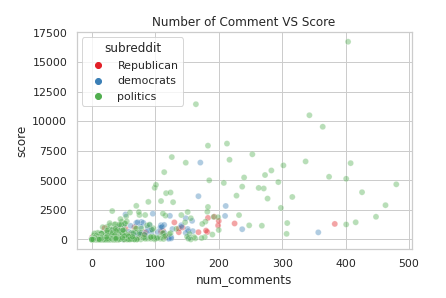

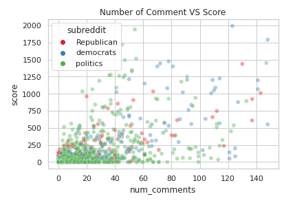

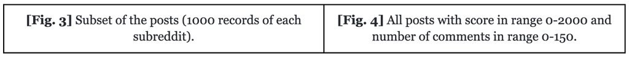

Figure 3 plot shows the relationship between the score and number of comments of all three subreddits. The dataset used in this plot is the subset of the original dataset, 1000 records of each subreddit - for scatter plot visibility. The score of most posts lay within the range of 0 to 2,000 and most of the number of comments lay within the range of 0 to 100. Both the scores and number of comments on the r/politics subreddits have a much wider range than other two subreddits. The post score has a roughly positive relationship with the number of comments - likely because the more people who upvote a post, the higher visibility it is on a subreddit which leads to more commenters. Figure 4 shows the same two variables with altered range, it shows the same positive relationship between these two variables.